# Исследование сетевых параметров публичных DNS серверов

## Цель работы

Проанализировать сетевые параметры публичных DNS серверов, сделать мотивированный вывод о предпочтительных серверах

## Используемое ПО

1. Windows 10
2. cmd
3. Rstudio IDE
4. tracert
5. 2ip
6. whois

## Варианты решения задачи

1. Решить задачу на Windows (с помощью утилиты tracert)
2. Решить задачу на Linux (с помощью утилиты tracerout)

## Общий план выполнения

1. Построить маршрут
2. С помощью whois, 2ip определить местоположение каждого узла маршрута к DNS-серверу, организацию, владеющую каждым узлом маршрута к DNS-серверу
3. Расчитать среднее RTT (время отправки + время обработки пакета на узле) к DNS-серверу
4. Выделить те узлы маршрута, которые вносят наибольшую временную задержку при передаче

## Исследуемые провайдеры DNS

1. Google Public DNS
2. Cloudflare DNS
3. OpenDNS
4. DNS вашего провайдера

## Ход работы

В сети Интернет доступ к вебсайтам осуществляется по их IP-адресам (например, 123.12.15.19) либо доменным именам. Соответствие между доменными именами и их адресами хранится в иерархической структуре службы доменных серверов - DNS-серверов. Чаще всего интернет-провайдер автоматически предоставляет своим пользователям собственный DNS-сервер, однако в некоторых случаях может потребоваться использовать публичные DNS сервера, бесплатно распространяемые в сети Интернет и доступные всем её пользователям.

Google Public DNS

```r
system("tracert 8.8.8.8", intern = TRUE)
```

```
##  [1] ""
##  [2] "’а ббЁа®ўЄ  ¬ аиагв  Є dns.google [8.8.8.8]"
##  [3] "б ¬ ЄбЁ¬ «мл¬ зЁб«®¬ Їал¦Є®ў 30:"
##  [4] ""
##  [5] "  1     2 ms     6 ms     2 ms  192.168.0.1 "
##  [6] "  2     4 ms     1 ms    <1 ¬б  172.18.0.1 "
##  [7] "  3    17 ms     9 ms    22 ms  gw-core.gptel.ru [77.73.25.1] "
##  [8] "  4    16 ms     7 ms    39 ms  77.94.162.77 "
##  [9] "  5     2 ms     1 ms     2 ms  ae3-nostromo-mtt-msk.naukanet.ru [77.94.160.52] "
## [10] "  6    13 ms     7 ms    11 ms  209.85.148.20 "
## [11] "  7    19 ms    30 ms     3 ms  108.170.250.66 "
## [12] "  8    20 ms    22 ms    24 ms  216.239.50.132 "
## [13] "  9    17 ms    17 ms    17 ms  216.239.54.48 "
## [14] " 10     *        *        *     ЏаҐўлиҐ ЁвҐаў « ®¦Ё¤ Ёп ¤«п § Їа®б ."
## [15] " 11     *        *        *     ЏаҐўлиҐ ЁвҐаў « ®¦Ё¤ Ёп ¤«п § Їа®б ."
## [16] " 12     *        *        *     ЏаҐўлиҐ ЁвҐаў « ®¦Ё¤ Ёп ¤«п § Їа®б ."
## [17] " 13     *        *        *     ЏаҐўлиҐ ЁвҐаў « ®¦Ё¤ Ёп ¤«п § Їа®б ."
## [18] " 14     *        *        *     ЏаҐўлиҐ ЁвҐаў « ®¦Ё¤ Ёп ¤«п § Їа®б ."
## [19] " 15     *        *        *     ЏаҐўлиҐ ЁвҐаў « ®¦Ё¤ Ёп ¤«п § Їа®б ."
## [20] " 16    18 ms    17 ms    20 ms  dns.google [8.8.8.8] "
## [21] ""
## [22] "’а ббЁа®ўЄ  § ўҐаиҐ ."
```

[output not shown]

Cloudflare DNS

```r
system("tracert 1.1.1.1", intern = TRUE)
```

```
##  [1] ""
##  [2] "’а ббЁа®ўЄ  ¬ аиагв  Є one.one.one.one [1.1.1.1]"
##  [3] "б ¬ ЄбЁ¬ «мл¬ зЁб«®¬ Їал¦Є®ў 30:"
##  [4] ""
##  [5] "  1     1 ms     1 ms     1 ms  192.168.0.1 "
##  [6] "  2     1 ms    <1 ¬б    <1 ¬б  172.18.0.1 "
##  [7] "  3     1 ms     3 ms     1 ms  gw-core.gptel.ru [77.73.25.1] "
##  [8] "  4    18 ms    32 ms     1 ms  gptel145.cln.net [79.98.8.145] "
##  [9] "  5     2 ms     2 ms    12 ms  jun0-mr-vl7.cln.net [79.98.8.254] "
## [10] "  6    20 ms    20 ms    20 ms  netnod-ix-ge-a-sth-1500.cloudflare.com [194.68.123.246] "
## [11] "  7    19 ms    21 ms    21 ms  one.one.one.one [1.1.1.1] "
## [12] ""
## [13] "’а ббЁа®ўЄ  § ўҐаиҐ ."
```

| № | Первый ping | Второй ping | Третий ping | Узел | Месторасположение | Организация | Средняя RTT | Вносит наибольшую временную задержку при передаче |
| --- | --- | --- | --- | --- | --- | --- | --- | --- |
| 1 | 1 ms | 1 ms | 1 ms | 192.168.0.1 | Москва | Домашний роутер | 1 |  |
| 2 | 1 ms | <1 ms | <1 ms | 172.18.0.1 | Москва | Гран При Телеком | 0,7 |  |
| 3 | 1 ms | 3 ms | 1 ms | gw-core.gptel.ru [77.73.25.1] | Москва | Гран При Телеком | 1,7 |  |
| 4 | 18 ms | 32 ms | 1 ms | gptel145.cln.net [79.98.8.145] | Москва | CLN | 17 | + |
| 5 | 2 ms | 2 ms | 12 ms | jun0-mr-vl7.cln.net [79.98.8.254] | Москва | CLN | 5,3 |  |
| 6 | 20 ms | 20 ms | 20 ms | netnod-ix-ge-a-sth-1500.cloudflare.com [194.68.123.246] | Borgholm, Sweden | Stockholm Interconnect GigEth | 20 | + |
| 7 | 19 ms | 21 ms | 21 ms | one.one.one.one [1.1.1.1] | Research, Australia | Cloudflare DNS | 20,3 | + |

OpenDNS

```r
system("tracert 208.67.220.220", intern = TRUE)
```

```
##  [1] ""
##  [2] "’а ббЁа®ўЄ  ¬ аиагв  Є resolver2.opendns.com [208.67.220.220]"
##  [3] "б ¬ ЄбЁ¬ «мл¬ зЁб«®¬ Їал¦Є®ў 30:"
##  [4] ""
##  [5] "  1    <1 ¬б    <1 ¬б    <1 ¬б  192.168.0.1 "
##  [6] "  2     1 ms     1 ms     1 ms  172.18.0.1 "
##  [7] "  3    10 ms     4 ms     1 ms  gw-core.gptel.ru [77.73.25.1] "
##  [8] "  4     1 ms     1 ms     1 ms  gptel145.cln.net [79.98.8.145] "
##  [9] "  5     4 ms     3 ms     3 ms  jun0-mr-vl7.cln.net [79.98.8.254] "
## [10] "  6     4 ms     2 ms     7 ms  ae11-747.RT.MR.MSK.RU.retn.net [87.245.253.18] "
## [11] "  7    42 ms    43 ms    39 ms  ae3-8.RT.TC2.AMS.NL.retn.net [87.245.233.17] "
## [12] "  8    57 ms    57 ms    57 ms  peer1.rtr1.ams.opendns.com [80.249.208.88] "
## [13] "  9    57 ms    57 ms    57 ms  resolver2.opendns.com [208.67.220.220] "
## [14] ""
## [15] "’а ббЁа®ўЄ  § ўҐаиҐ ."
```

[output not shown]

ООО “Гран При Телеком”

```r
system("tracert 77.73.24.2", intern = TRUE)
```

```
##  [1] ""
##  [2] "’а ббЁа®ўЄ  ¬ аиагв  Є ns.gptel.ru [77.73.24.2]"
##  [3] "б ¬ ЄбЁ¬ «мл¬ зЁб«®¬ Їал¦Є®ў 30:"
##  [4] ""
##  [5] "  1     3 ms     1 ms     1 ms  192.168.0.1 "
##  [6] "  2     1 ms    <1 ¬б    <1 ¬б  172.18.0.1 "
##  [7] "  3     1 ms     1 ms     1 ms  gw-aggr1.gptel.ru [77.73.25.6] "
##  [8] "  4     1 ms     1 ms     1 ms  ns.gptel.ru [77.73.24.2] "
##  [9] ""
## [10] "’а ббЁа®ўЄ  § ўҐаиҐ ."
```

| № | Первый ping | Второй ping | Третий ping | Узел | Месторасположение | Организация | Средняя RTT | Вносит наибольшую временную задержку при передаче |
| --- | --- | --- | --- | --- | --- | --- | --- | --- |
| 1 | 3 ms | 1 ms | 1 ms | 192.168.0.1 | Москва | Домашний роутер | 1,7 | + |
| 2 | 1 ms | <1 ms | <1 ms | 172.18.0.1 | Москва | Гран При Телеком | 0,7 |  |
| 3 | 1 ms | 1 ms | 1 ms | gw-aggr1.gptel.ru [77.73.25.6] | Москва | Гран При Телеком | 1 | + |
| 4 | 1 ms | 1 ms | 1 ms | ns.gptel.ru [77.73.24.2] | Москва | network for GRANDPRIX Telecom | 1 | + |

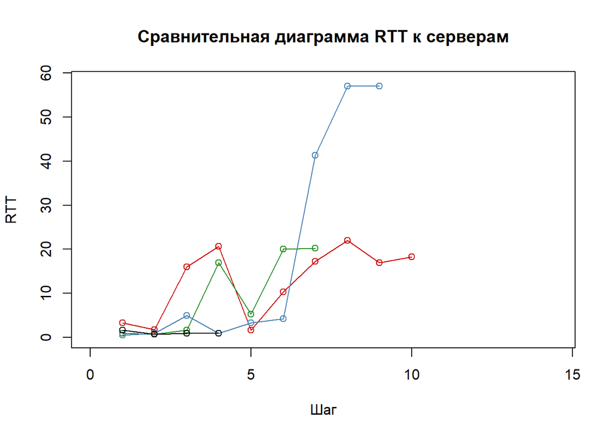

Красный - Google Public DNS

Зеленый - Cloudflare DNS

Синий - OpenDNS

Черный - ООО “Гран При Телеком”

## Оценка результата

На графике видно, что больше всего времени потребовалось при обращении к OpenDNS, меньше всего - к ООО “Гран При Телеком”.

## Вывод

DNS важна для работы Интернета, так как для соединения с узлом необходима информация о его IP-адресе, а для людей проще запоминать буквенные (обычно осмысленные) адреса, чем последовательность цифр IP-адреса. В данной лабораторной работе мы рассмотрели параметры Google Public DNS, Cloudflare DNS, OpenDNS, ООО “Гран При Телеком”.